# Weber’s Law:

Weber’s Law: Linear Relationships in Psychophysics and how to Model them with `R` in the tidyverse Bonnie Cooper, PhD

[figure not shown]

## An Introduction to Weber’s Law

Visual environments and the minds that perceive them are complex. Psychophysics is an branch off the psychology tree which aims to quantify the relationships between physical stimuli in the environment and their internal representation, or perception, experienced by observers.$^2$ Here we will look at a psychophysical phenomenon, **Weber’s Law**, that describes the simple linear relationship between changes in intensity of a stimulus and the way the sensation of the change is perceived by human subjects.

In 1846, Ernst Weber described a relationship where “the minimum increase of stimulus which will produce a perceptible increase of sensation is proportional to the pre-existent stimulus”. In other words, as a stimulus intensity increases, so to does the increment of change such that the observer can perceive a difference in intensity. The minimum increment of stimulus needed to be detected by a subject is also called the **just noticeable difference (jnd)**.$^1$ Another way to state Weber’s Law is that the jnd increases at a constant rate as stimulus intensity increases, which Gustav Fetchner (the godfather of psychophysics) summarized in this simple equation:
$$\frac{jnd}{I} = k$$
where $I$ is the intensity of the stimulus and $k$ is the value of the constant that describes the relationship.
Remarkably, Weber’s Law has been demonstrated for just about every mode of sensation available to study. The proportional relationship between jnd and intensity remains the same whether describing visual, auditory or tactile increments while the constant, $k$ changes to describe each process. In this post, we will walk through an illustration of Weber’s Law for a visual psychophysics experiment and find the constant, $k$, by way of linear regression in `R`.

First, import the `R` libraries that will be used for this analysis:

```r
library( ggplot2 )
library( dplyr )
library( tidyverse )
library( broom )
```

## Demonstrating Weber’s Law

Interestingly, Weber’s Law had actually been described for visual stimuli long before it was declared. In the late 1700s a French scientist, Pierre Bouger, made the observation that his ability to detect his shadow cast by a candle onto a screen was proportional to the screen’s illumination by another candle placed behind it. Since Bouger and following Weber, many investigators have looked at jnds of visual stimuli$^3$. For example, the following code reproduces the results from Cornsweet and Pinsker (1965) for a subject performing 3 different luminance discrimination tasks$^4$.

- Task 1: discriminate 2 flashed discs presented briefly on a dark background. Which disc was brighter?
- Task 2: 2 equal discs are present (on constantly) and one briefly changes intensity. Which disc became brighter?
- Task 3: 2 equal discs are present before a trial, however, they extinguish ~5 seconds before two test discs are shown. Which test disc is brighter?

Let’s take a look at data that was adapted from Cornsweet & Pinsker (1965, Fig. 4). We’ll observe how a simple linear regression can be applied to find the constant, $k$:

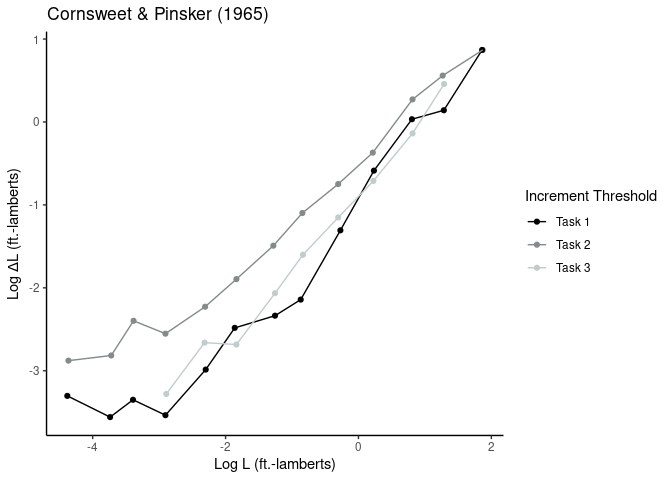

```r
url <- 'https://raw.githubusercontent.com/SmilodonCub/DATA621/master/cornsweet_AllExp.csv'
cornsweet_df <- read.csv( url )
ggplot( data = cornsweet_df, aes( x = x, y = y, col = factor( Exp ) ) ) +
  geom_point() +
  geom_line() +
  theme_classic() +
  scale_color_manual(labels = c("Task 1", "Task 2", "Task 3"), values = c("black", "azure4", "azure3") ) +
  labs( title = "Cornsweet & Pinsker (1965)", x = "Log L (ft.-lamberts)",
        y = expression( paste( "Log ", Delta, "L (ft.-lamberts)" ) ), color = 'Increment Threshold' )
```

In the figure above, the observer’s jnd ( Log $\Delta$L, y-axis) is plotted as a function of the stimulus intensity (Log L, x-axis). We see that, for most of the stimulus’s luminance range, the data points follow a clear linear envelope. The major points of deviation from linearity occur for Task 1 & 2 at very low levels of stimulus intensity.

In the following code, we will model the subjects response as a linear regression and compare the fits between tasks:

```r
cornsweet_lms <- cornsweet_df %>%
  nest( -Exp ) %>%
  mutate( fit = map( data, ~ lm( y ~ x, data = . ) ),
          cornsweet_lms_res = map( fit, augment ) ) %>%
  unnest( cornsweet_lms_res )
```

Visualize the data for each task with the corresponding linear regression fit:

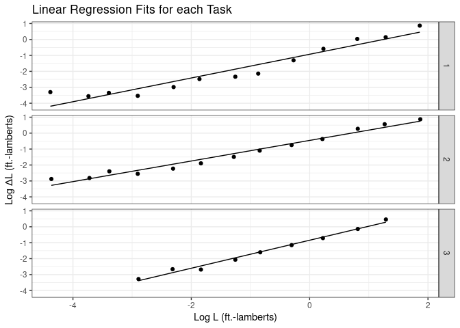

```r
cornsweet_lms %>%
  ggplot( aes( x = x, y = .fitted ) ) +
  geom_line() +
  geom_point( aes( x = x, y = y ) ) +
  facet_grid( Exp ~ . ) +
  theme_bw() +
  labs( title = "Linear Regression Fits for each Task", x = "Log L (ft.-lamberts)",
        y = expression( paste( "Log ", Delta, "L (ft.-lamberts)" ) ) )
```

We can see that Tasks 1 & 2 have greater deviations from the fitted regression line, but let’s get a better look by plotting the residuals directly.

Visualize the residuals for each task’s linear model fit:

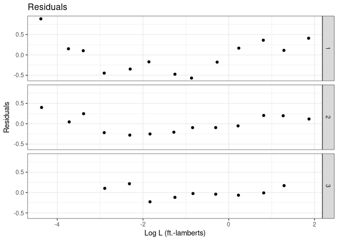

```r
cornsweet_lms %>%
  ggplot( aes( x = x, y = .resid ) ) +
  geom_point() +
  facet_grid( Exp ~ . ) +
  theme_bw() +
  labs( title = "Residuals", x = "Log L (ft.-lamberts)", y = expression( "Residuals" ) )
```

The data for Task 3 does not extend into the same lower intensity range (<-3) as Task 1 & 2 where their residuals are greatest. As a result, a linear model accounts for more variance for Task 3’s data. We can demonstrate this by calculating the $R^2$ for each linear fit.

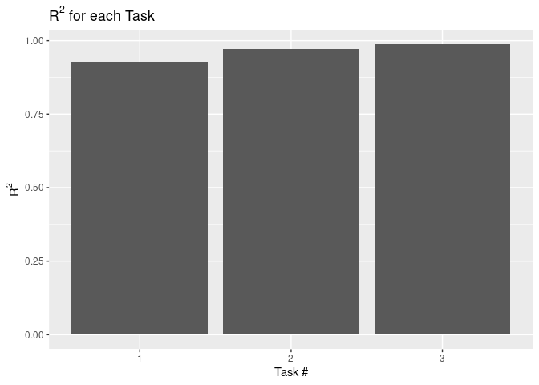

```r
cornsweet_R2 <- cornsweet_df %>%
  nest( -Exp ) %>%
  mutate( fit = map( data, ~ lm( y ~ x, data = . ) ),
          cornsweet_lms_res = map( fit, glance ) ) %>%
  unnest( cornsweet_lms_res ) %>%
  ggplot( aes( x = factor( Exp ), y = r.squared ) ) +
  geom_bar( stat = "identity" ) +
  labs( title = expression( paste( R^{2}, ' for each Task') ), x = "Task #", y = expression( R^{2} ) )
cornsweet_R2
```

The $R^2$ values are all very close to 1 indicating a very good linear fit, especially considering that these measurements were acquired from a human psychophysics subject. The slope of each of the regression lines can be interpreted as the constant, $k$, also known as the **Weber Fractions**.

Weber Fraction for Cornsweet & Pinsker tasks:

- Task 1 $\frac{jnd}{I}=$ 0.7443
- Task 2 $\frac{jnd}{I}=$ 0.6462
- Task 3 $\frac{jnd}{I}=$ 0.8781

The slope ($k$, Weber’s Fraction) for Task 3 is greater than Tasks 1 & 2 and Task 3 has the highest $R^2$ value. This is due to the residuals with relatively high magnitudes obtained for discrimination thresholds at very low luminance intensities. But these tasks seem very similar….Why would there be any difference in linear fits between the three tasks at all? The experimentors manipulated the adaptation state of the subjects before the stimulus discs were flashed on the screen; this was done to try to extend the linear range of the Weber’s Law relationship for Task 3. Do you think they were successful?….

Please refer to the original paper for more details about the task and experimental design.

### the Take Home

Weber’s Law demonstrates that despite the difficult task of representing our environment, simple relationships that describe our sensation of a complicated world can be found. The data and code above walk us through a classic finding in visual psychophysics. However, similar relationships for other sensory modalities and in many other species have been described.$^5$ Gustav Fetchner and Ernst Weber first described the situation of tactile weight discrimination: For a subject to be able to discriminate the weight of two objects, the difference in weight has to increase proportionally to the weight of the objects. For example, it is much easier to tell the difference between two objected weighing 5lbs and 6lbs than two objects weighing 55lbs and 56lbs. Additionally, Weber’s Law has also been applied to human factors for business strategy where a 1$ discount for a 3$ product is definitely perceived favorably over a 1$ discount for a 80$ product.

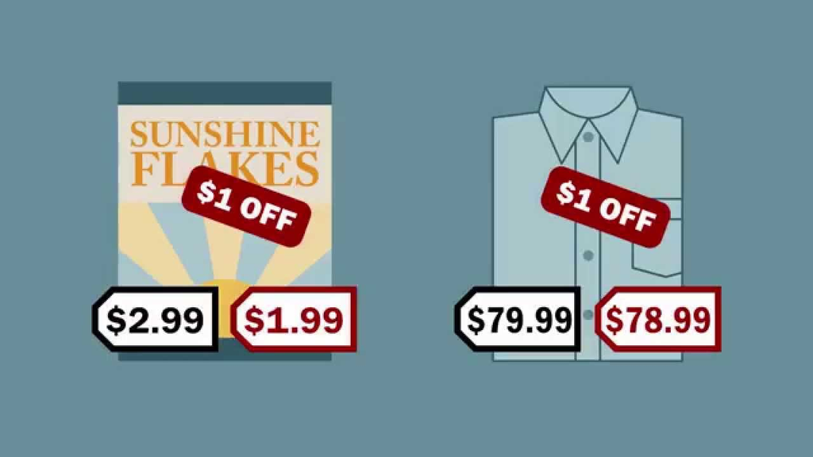

## References

1. Lu, Z. L., & Dosher, B. (2013). Visual Psychophysics: From laboratory to theory. MIT Press.
2. Palmer, S. E. (1999). Vision science: Photons to phenomenology. MIT press.
3. Barlow, H. B. (1957). Increment thresholds at low intensities considered as signal/noise discriminations. The Journal of Physiology, 136(3), 469-488.
4. Cornsweet, T. N., & Pinsker, H. M. (1965). Luminance discrimination of brief flashes under various conditions of adaptation. The Journal of Physiology, 176(2), 294-310.
5. Laming, D. (2009). Weber’s law. In Insid. Psychol. a Sci. over 50 years. Oxford University Press.